# Personalysis and Strength Profile - Clinical Analytics

## John

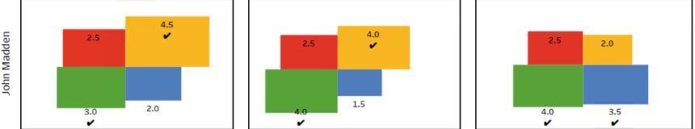

## Jonathan

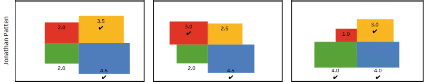

## Kevin

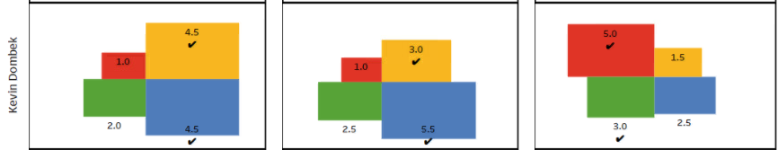

## Keyana

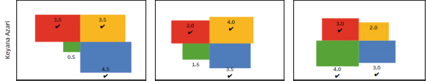

## Laurel

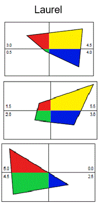

## Linda

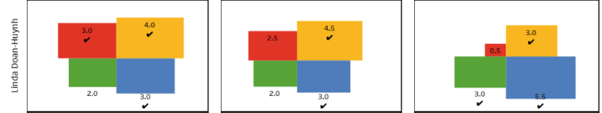

## Lizbeth

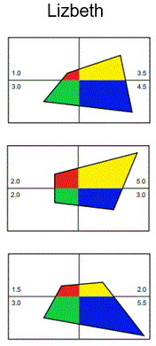

## Mauli

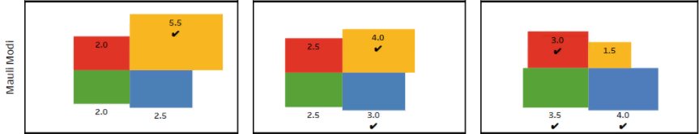

## Sarah

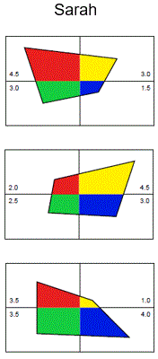

## Ngoc

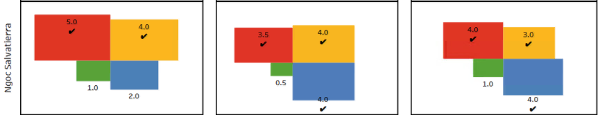

## Susan H

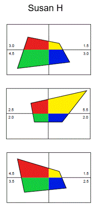

## Susan P

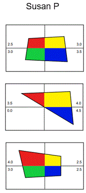

## Suzanne

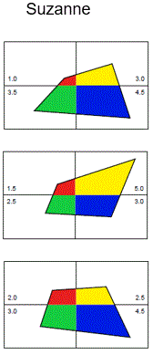

## Tom

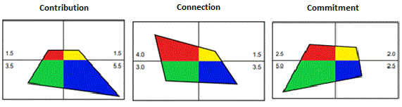

## Others

Others pending.

[figure not shown]

# Personalysis Clustering: Homogeneity within Colors

## **Red** (Expadite)

**RED** is motivated to **intitiate action** and **stay moving**. They stay focused on tasks and tangible outcomes. They have high energy, intense focus, and a sense of urgency. Cluster results below devide individuals into 3 homogeneous groups: first at a high level among all Red scores combined and then within each of the Red sub-scores for Contribution, Connection and Commitment.

*Average in parentheses

### COMBINED

[interactive chart not shown]

*Score in parentheses

### Contribution

[interactive chart not shown]

### Connection

*Score in parentheses

[interactive chart not shown]

### Commitment

*Score in parentheses

[interactive chart not shown]

## **Blue** (Expore)

**Blue** is motivated to **anticipate** the future and **create clarity**. They focus on context, purpose and potential impacts. They are curious, innovative, and sensitive to subtleties. Cluster results below devide individuals into 3 homogeneous groups: first at a high level among all Blue scores combined and then within each of the Blue sub-scores for Contribution, Connection and Commitment.

### COMBINED

*Average in parentheses*

[interactive chart not shown]

### Contribution

*Score in parentheses

[interactive chart not shown]

### Connection

*Score in parentheses

[interactive chart not shown]

### Commitment

*Score in parentheses

[interactive chart not shown]

## **Green** (Organize)

**Green** is motivated to **maintain stability** and **organization**. They focus on details, structure and predictability. They are analytical, methodical, and systematic. Cluster results below devide individuals into 3 homogeneous groups: first at a high level among all Green scores combined and then within each of the Green sub-scores for Contribution, Connection and Commitment.

### COMBINED

*Average in parentheses*

[interactive chart not shown]

### Contribution

*Score in parentheses

[interactive chart not shown]

### Connection

*Score in parentheses

[interactive chart not shown]

### Commitment

*Score in parentheses

[interactive chart not shown]

**YELLOW** is motivated to **adapt** and be **flexible**. They focus on people and possibilites. They attune to their environment and are highly responsive and optimistic. Cluster results below devide individuals into 3 homogeneous groups: first at a high level among all Yellow scores combined and then within each of the Yellow sub-scores for Contribution, Connection and Commitment.

### COMBINED

*Average in parentheses*

[interactive chart not shown]

### Contribution

*Score in parentheses

[interactive chart not shown]

### Connection

*Score in parentheses

[interactive chart not shown]

### Commitment

*Score in parentheses

[interactive chart not shown]

# Clifton Strength Profile - Top Five Strengths

[figure not shown]

## By Responder

**Top Five Strengths: By Responder**

[interactive chart not shown]

## All Top Five Strengths

**All Top Five Strengths**

[interactive chart not shown]

## All Top Five Strengths - Ordered

**All Top Five Strengths - Ordered**

[interactive chart not shown]

# Table of Results

|  | Name | r1 | y1 | b1 | g1 | r2 | y2 | b2 | g2 | r3 | y3 | b3 | g3 | 1 | 2 | 3 | 4 | 5 |
| --- | --- | --- | --- | --- | --- | --- | --- | --- | --- | --- | --- | --- | --- | --- | --- | --- | --- | --- |
| 1 | Gino Conconi | 2.5 | 4.5 | 1 | 4 | 2 | 6 | 3 | 1 | 2 | 2 | 3.5 | 4.5 | Deliberative | Relator | Context | Competition | Connectedness |
| 2 | Jacob Lippa | 1 | 4.5 | 4 | 2.5 | 4.5 | 2 | 4.5 | 1 | 2 | 2.5 | 3 | 4.5 | Adaptability | Ideation | Analytical | Strategic | Relator |
| 3 | Suzanne Campbell | 1 | 3 | 4.5 | 3.5 | 1.5 | 5 | 3 | 2.5 | 2 | 2.5 | 3 | 4.5 | Discipline | Harmony | Arranger | Connectedness | Restorative |
| 4 | Susan Hermanto | 3 | 1.5 | 3 | 4.5 | 2.5 | 5.5 | 2 | 2 | 4.5 | 1.5 | 2.5 | 3.5 | Learner | Achiever | Deliberative | Relator | Restorative |
| 5 | Firouzeh Manucheri | 3 | 4.5 | 2.5 | 2 | 2 | 5 | 4 | 1 | 3 | 2.5 | 3.5 | 3 | Individualixation | Activator | Analytical | Ideation | Deliberative |
| 6 | Lizbeth McNeil | 1 | 3.5 | 4.5 | 3 | 2 | 5 | 3 | 2 | 1.5 | 2 | 3 | 5.5 | Developer | Empathy | Positivity | Adaptability | Strategic |
| 7 | Laurel Kirby | 3 | 4.5 | 4 | 0.5 | 1.5 | 5.5 | 3 | 2 | 5 | 0.01 | 2.5 | 4.5 | Achiever | Relator | Learner | Individualixation | Input |
| 8 | Sarah Nurse | 4.5 | 3 | 1.5 | 3 | 2 | 4.5 | 3 | 2.5 | 3.5 | 1 | 4 | 3.5 | Strategic | Relator | Activator | Analytical | Self-Assurance |
| 9 | Ari Robicsek | 4 | 4 | 3.5 | 0.5 | 3.5 | 3.5 | 3.5 | 1.5 | 3 | 2 | 4 | 3 | Achiever | Strategic | Learner | Intellection | Input |
| 10 | Jacob VanderKam | 3 | 4 | 3 | 2 | 2 | 4.5 | 4 | 1.5 | 4 | 3.5 | 1.5 | 3 | Ideation | Strategic | Input | Restorative | Achiever |

[output cut: 33 more lines]